# Fansler et al., Nature Communications, Suppl. Figures 4g-l

Sibylle Mitschka

Loading of R packages and set working directory.

```r
library(tidyverse)
library(broom)
library(Biostrings)
library(ggpubr)
library(rtracklayer)
library(org.Hs.eg.db)
library(RColorBrewer)
library(biomaRt)
library(GenomicFeatures)
library(BSgenome)
library(GeneOverlap)
library(pheatmap)
library(biomaRt)
library(plyranges)
library(ggrepel)
library(writexl)
library(gridExtra)
library(readxl)
```

How often are multi-UTR genes effectively single-UTR genes across the different cell types?

```r
### Deduce the effective number of cell number from the number of cells that the highest expressed genes are detected in.

n_cells_tissue_hs <- read_delim("input_data/tpm_celltypes/hg38/merged_ncells_expr.tsv") %>%
  pivot_longer(cols=c(8:410), names_to="Tissue", values_to = "cells") %>%
  group_by(Tissue) %>%
  slice_max(cells, with_ties=FALSE, n=1) %>%
  ungroup() %>%
  select(Tissue, cells)
### This creates the list of cell types that we want to analyze (234 cell types).

Tissues_high_hs <- n_cells_tissue_hs %>%
  dplyr::filter(cells>199) %>%
  pull(Tissue) %>%
  unlist()

### Load all count data and subset to the relevant cell type samples.

atlas_human_filt <- read_delim("input_data/tpm_celltypes/hg38/merged_tx_tpm_pointestimates.tsv.gz") %>%
   pivot_longer(cols=c(21:423), names_to="Tissue", values_to = "TPM") %>%
   dplyr::filter(Tissue %in% Tissues_high_hs)
### Calculate total gene expression count with and without considering IPA expression

atlas_human_gene_TPMs <- atlas_human_filt %>%
  group_by(gene_name, gene_id, Tissue) %>%
  summarize(TPM_gene = sum(TPM, na.rm=T),
            TPM_gene_woIPA = sum(TPM[is_ipa==FALSE], na.rm=T))
### Combine both data tables and calculate the fractional expression of each isoform within tissues

atlas_human_filt1 <- atlas_human_filt %>%
  left_join(., atlas_human_gene_TPMs, by=c("gene_name", "gene_id", "Tissue")) %>%
  mutate(frac_tx_to_gene= TPM/TPM_gene,
         frac_tx_to_gene_woIPA = TPM/TPM_gene_woIPA)
```

```r
### Filter to genes and tissues were the gene has a total expression level (excluding IPA) above 5 TPM. Restrict to isoforms with a relative expression ratio higher than 0.1. Here we exclude IPA isoforms.

atlas_human_filt1.1 <- atlas_human_filt1 %>%
  dplyr::filter(is_ipa==FALSE,
                TPM_gene_woIPA > 5,
                frac_tx_to_gene_woIPA > 0.1)

# For each gene, calculate the fraction of tissues at which it has more than 1 isoform (effectively multi-UTR)

histo_genes_human <- atlas_human_filt1.1 %>%
  dplyr::filter(atlas.utr_type=="multi") %>%
  group_by(Tissue, gene_name) %>%
  count() %>%
  ungroup() %>%
  mutate(multi=ifelse(n>1, TRUE, FALSE)) %>%
  group_by(gene_name) %>%
  summarize(multi_ratio = mean(multi, na.rm=T))

### Create a distribution of these ratios and define marks at 0.25 and 0.75.

histogram_human <- histo_genes_human %>% ggplot(aes(x = multi_ratio)) +
  geom_histogram() +
  scale_x_continuous(expand = c(0,0)) +
  geom_vline(xintercept = 0.25) +
  geom_vline(xintercept = 0.75) +
  theme_bw()

## Calculate the total fraction of multi-UTR genes that are either rarely Multi-UTR (less than a quarter of tissues), or mostly multi_UTYR (in more than three quarters of tissues). Save the histogram.

histo_genes_human %>% summarize(mean = mean(multi_ratio<0.25))
```

| mean |
| --- |
| 0.1742121 |

```r
histo_genes_human %>% summarize(mean = mean(multi_ratio>0.75))
```

| mean |
| --- |
| 0.6249375 |

```r
ggsave("Figure_outputs/Sup_Fig4g.pdf", histogram_human)
```

Next, we are creating another visualization of the expression phenotype of multi-UTR genes across all the analyzed tissues. This will be a categorical evaluation with the following categories: 1. The gene is expressed above 5 TPM and has more than 1 isoform with >0.1 expression ratio (teal). 2. The gene is expressed above 5 TPM and has exactly 1 isoform with >0.1 expression ratio (purple). 3. The gene is expressed <5TPM (white).

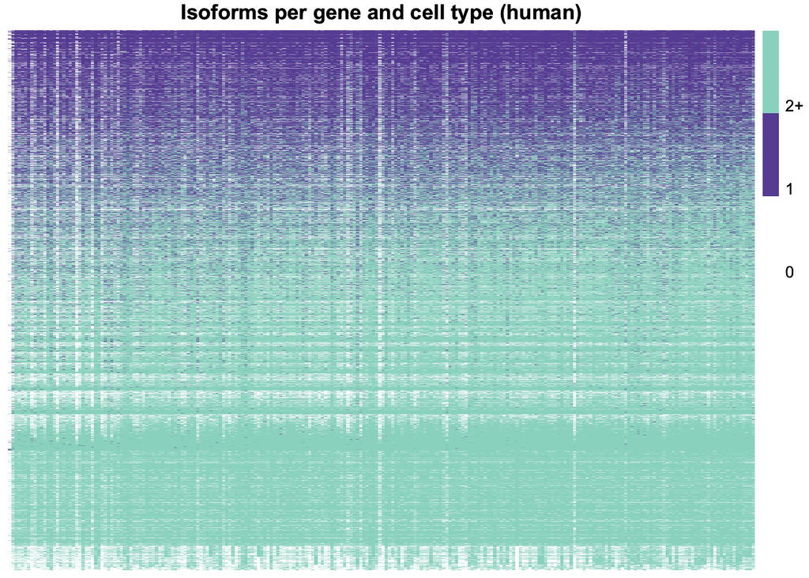

```r
### Count the number of isoforms per gene and tissue in a new table

atlas_human_filt1_tx <- atlas_human_filt1.1 %>%
  group_by(Tissue, gene_name, gene_id) %>%
  count() %>%
  ungroup()

### To order the tissues in the final tile plot (heatmap), we want to calculate the fraction of genes that present as multi-UTR genes (from rarely to mostly). This is saved in "tissue_order".

atlas_human_multi <- atlas_human_filt1_tx %>%
  group_by(Tissue) %>%
  summarize(genes = length(gene_id),
            multi_frac = mean(n>1),
            multi_n = multi_frac*genes) %>%
  dplyr::arrange(multi_frac)

tissue_order_human <- atlas_human_multi %>%
  pull(Tissue) %>%
  unlist()

### To order the genes in the final tile plot (heatmap), we will calculate the fraction of tissues in which the gene presents as multi-UTR gene (from rarely to mostly). This is saved in "gene_order_human".

gene_order_human <- atlas_human_filt1.1 %>%
  group_by(Tissue, gene_name) %>%
  count() %>%
  ungroup() %>%
  mutate(multi=ifelse(n>1, TRUE, FALSE)) %>%
  group_by(gene_name) %>%
  summarize(multi_ratio = mean(multi, na.rm=T)) %>%
  dplyr::arrange(multi_ratio)

### We will further restrict the representation to those genes that have expression values above 5TPM in a large number of smaples.

atlas_human_filt1_matrix <- atlas_human_filt1.1 %>%
  dplyr::filter(atlas.utr_type=="multi") %>%
  group_by(Tissue, gene_name) %>%
  count() %>%
  ungroup() %>%
  mutate(n=ifelse(n>2, 2, n))%>%
  pivot_wider(id_cols=gene_name, names_from = Tissue, values_from=n, values_fill = 0) %>%
  column_to_rownames(var="gene_name") %>%
  dplyr::filter(rowSums(.,na.rm=T)>126) %>%
  rownames_to_column(var="gene_name") %>%
  left_join(gene_order_human, by= "gene_name") %>%
  dplyr::arrange(multi_ratio) %>%
  dplyr::select(tissue_order_human)
breaks=c(0, 0.9, 1.9, 2.9)
color=c("white","#6a51a3","#99d8c9")

heatmap_human <- pheatmap(atlas_human_filt1_matrix,
         breaks=breaks,
         cluster_rows=F,
         cluster_cols=F,
         color=color,
         show_rownames = FALSE,
         show_colnames = FALSE,
         main= "Isoforms per gene and cell type (human)",
         legend_breaks = 0:2,
         legend_labels = c("0","1", "2+"))

heatmap_human
```

```r
ggsave("Figure_outputs/Sup_Fig4h.pdf", heatmap_human)
```

In order to analyze expression associated with different CS, we need to: 1. subset to those isoforms where merging does not occur (16,509 out of 49,410 isoforms). 2. subset to the cell type samples with 200 and more cell types (234 out of 403 human cell types). 3. restrict analysis to multi-UTR genes with 5 TPM or higher expression (variable across cell types).

```r
CS_hs <- read_csv("input_data/MWS_data/Human_MWS_CS_Annotation.csv")
transcripts_hs <- read_excel("input_data/MWS_data/Human_Gene_Annotation.xlsx", sheet = "Transcripts - Human UTRome")

### Subset to multi_UTR genes with >5 TPM total expression, add group labels according to annotation.

atlas_human_filt2 <- atlas_human_filt1 %>%
  dplyr::filter(is_ipa==FALSE, atlas.utr_type=="multi", TPM_gene_woIPA > 5) %>%
  group_by(gene_name, gene_id, transcript_id) %>%
  summarize(median_usage = median(frac_tx_to_gene_woIPA, na.rm=TRUE),
            mean_usage = mean(frac_tx_to_gene_woIPA, na.rm=TRUE),
            sd_usage = sd(frac_tx_to_gene_woIPA, na.rm=TRUE)) %>%
  left_join(transcripts_hs, by= c("gene_name", "gene_id", "transcript_id")) %>%
  mutate(n_merged_tx= str_count(merged_txs, "ENST")) %>%
  dplyr::filter(n_merged_tx==1, atlas.utr_type=="multi") %>%
  left_join(CS_hs, by= c("gene_name", "gene_id", "transcript_id")) %>%
  mutate(category= case_when(n_celltypes_tx>0 & is_novel==FALSE ~ "Common",
    n_celltypes_tx==0 & is_novel==FALSE ~ "GENCODE-only",
    n_celltypes_tx>0 & is_novel==TRUE ~ "MWS-only"),
    category= factor(category, levels=c("Common", "MWS-only", "GENCODE-only"))) %>%
  ungroup()
```

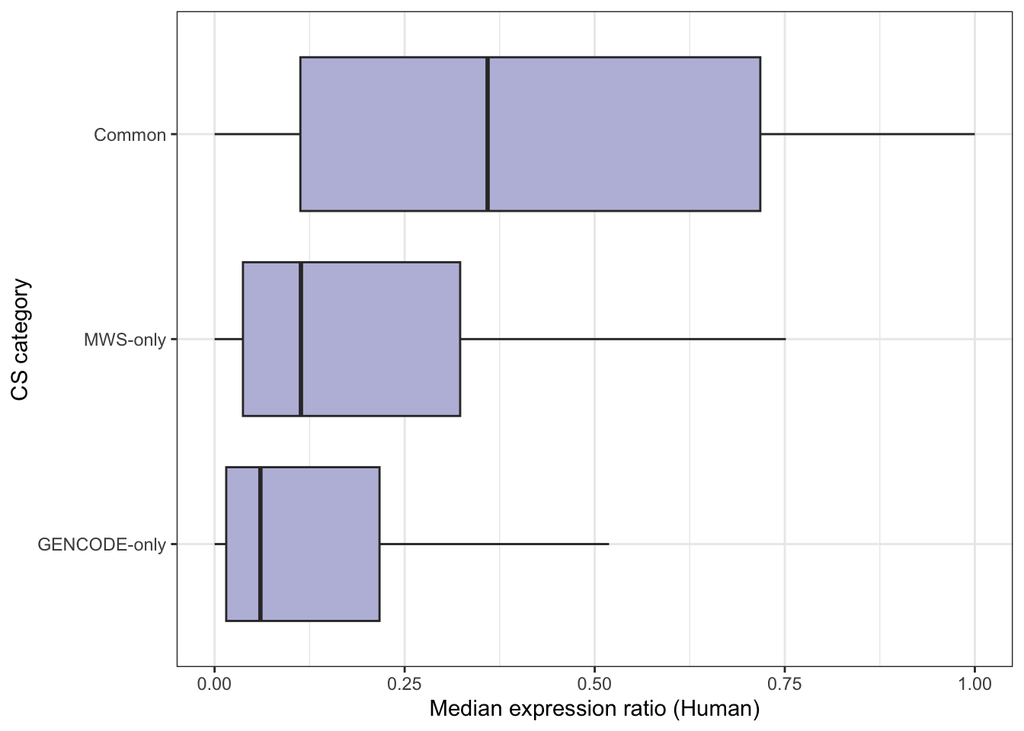

```r
### Plot fractional expression (proxy for usage) of Common, MWS-only and GENCODE-only isoforms.

plot_expr_commonunique_hs <- atlas_human_filt2 %>%
  ggplot(aes(x= median_usage, y= reorder(category, median_usage))) +
  geom_boxplot(fill= "#bcbddc", outlier.shape = NA) +
  scale_y_discrete("CS category") +
  scale_x_continuous("Median expression ratio (Human)") +
  theme_bw()
plot_expr_commonunique_hs
```

```r
### calculate median fractional expression in each group.

atlas_human_filt2 %>% group_by(category) %>%
  summarize(median(median_usage, na.rm=TRUE))
```

| category | median(median_usage, na.rm = TRUE) |
| --- | --- |
| Common | 0.35910490 |
| MWS-only | 0.11356170 |
| GENCODE-only | 0.06028568 |

```r
### calculate fraction of minor isoforms with a median use above 0.33.

atlas_human_filt2 %>%
  dplyr::filter(cs_usage_class=="minor") %>%
  summarize(mean = mean(median_usage >0.33))
```

| mean |
| --- |
| 0.1442272 |

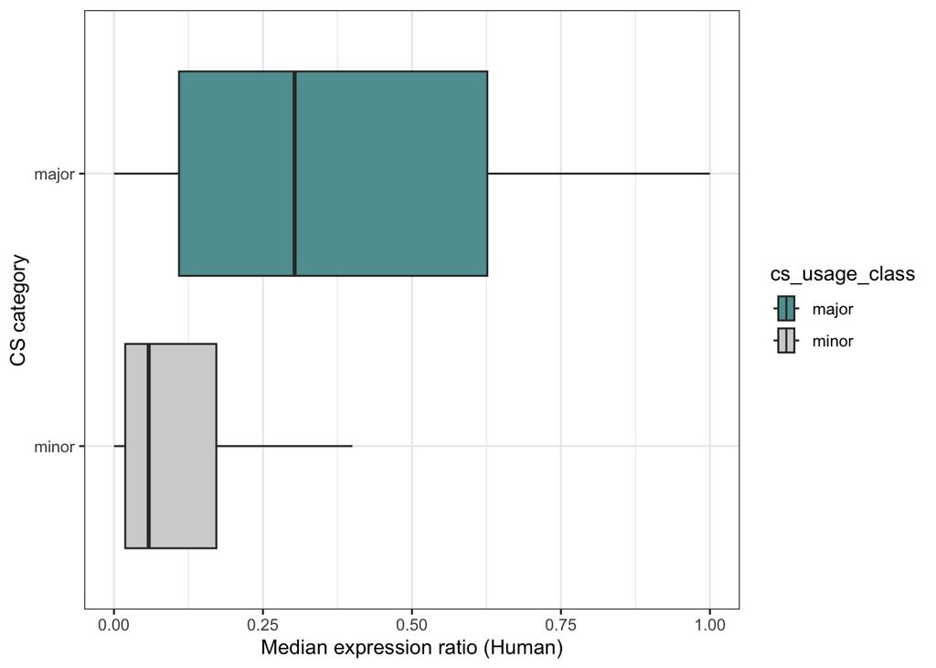

```r
### Plot fractional expression of major and minor isoforms.

plot_expr_majorminor_hs <- atlas_human_filt2 %>%
  dplyr::filter(!is.na(cs_usage_class)) %>%
  ggplot(aes(x= median_usage, y=reorder(cs_usage_class, median_usage), fill=cs_usage_class)) +
  geom_boxplot(outlier.shape = NA) +
  scale_fill_manual(values=c("cadetblue", "lightgrey"))+
  scale_y_discrete("CS category") +
  scale_x_continuous("Median expression ratio (Human)") +
  theme_bw()
plot_expr_majorminor_hs
```

```r
atlas_human_filt2 %>%
  group_by(cs_usage_class) %>%
  dplyr::filter(!is.na(cs_usage_class)) %>%
  summarize(median(median_usage, na.rm=TRUE))
```

| cs_usage_class | median(median_usage, na.rm = TRUE) |
| --- | --- |
| major | 0.3030435 |
| minor | 0.0582043 |

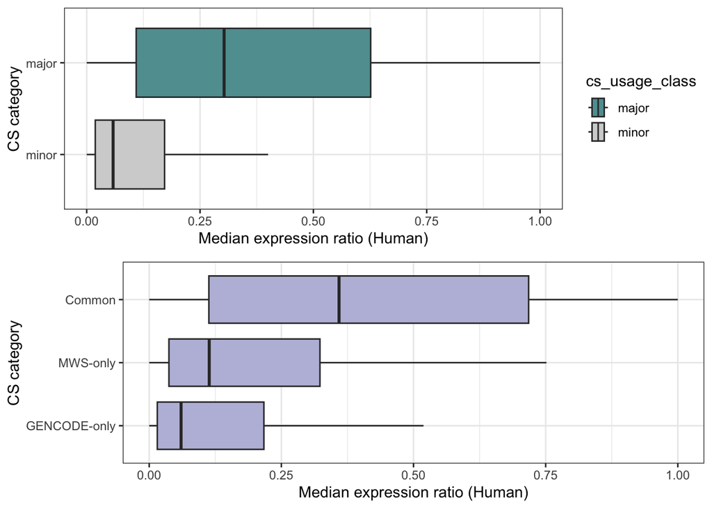

```r
human_expr_plots <- grid.arrange(plot_expr_majorminor_hs, plot_expr_commonunique_hs)
```

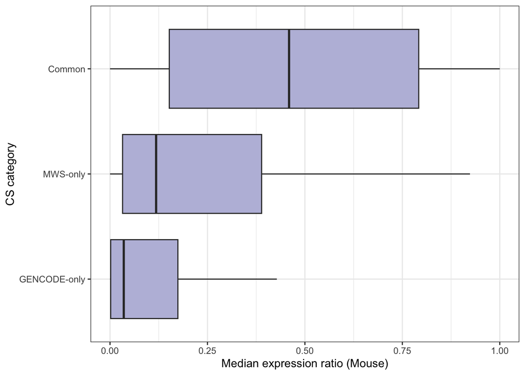

```r
ggsave("Figure_outputs/Sup_Fig4k.pdf", human_expr_plots)
CS_mm <- read_csv("input_data/MWS_data/Mouse_MWS_CS_Annotation.csv")
transcripts_mm <- read_excel("input_data/MWS_data/Mouse_Gene_Annotation.xlsx", sheet = "Transcripts - Mouse UTRome")

### Deduce cell number from the number of cells the highest expressed genes are expressed in.

n_cells_tissue_mm <- read_delim("input_data/tpm_celltypes/mm10/merged_ncells_expr.tsv") %>%
  pivot_longer(cols=c(8:152), names_to="Tissue", values_to = "cells") %>%
  group_by(Tissue) %>%
  slice_max(cells, with_ties=FALSE, n=1) %>%
  ungroup() %>%
  select(Tissue, cells)
### This creates the list of cell types that we want to analyze (82 cell types).

Tissues_high_mm <- n_cells_tissue_mm %>%
  dplyr::filter(cells>199) %>%
  pull(Tissue) %>%
  unlist()

### load all cell type data and subset to the one with more than 200 cells.

atlas_mouse_filt <- read_delim("input_data/tpm_celltypes/mm10/merged_tx_tpm_pointestimates.tsv.gz") %>%
   pivot_longer(cols=c(21:165), names_to="Tissue", values_to = "TPM") %>%
   dplyr::filter(Tissue %in% Tissues_high_mm)
### Calculate total expression per gene for each tissue.

atlas_mouse_gene_TPMs <- atlas_mouse_filt %>%
  group_by(gene_name, gene_id, Tissue) %>%
  summarize(TPM_gene = sum(TPM, na.rm=T),
            TPM_gene_woIPA = sum(TPM[is_ipa==FALSE], na.rm=T))
### Combine both data and calculate the fractional use of each isoform per tissue.

atlas_mouse_filt1 <- atlas_mouse_filt %>%
  left_join(., atlas_mouse_gene_TPMs, by=c("gene_name", "gene_id", "Tissue")) %>%
  mutate(frac_tx_to_gene= TPM/TPM_gene,
         frac_tx_to_gene_woIPA = TPM/TPM_gene_woIPA)

### Subset to multi_UTR genes with >5 TPM total expression, add group labels according to annotation.

atlas_mouse_filt2 <- atlas_mouse_filt1 %>%
  dplyr::filter(is_ipa==FALSE, atlas.utr_type=="multi", TPM_gene_woIPA > 5) %>%
  group_by(gene_name, gene_id, transcript_id) %>%
  summarize(median_usage = median(frac_tx_to_gene_woIPA, na.rm=TRUE),
            mean_usage = mean(frac_tx_to_gene_woIPA, na.rm=TRUE),
            sd_usage = sd(frac_tx_to_gene_woIPA, na.rm=TRUE)) %>%
  left_join(transcripts_mm, by= c("gene_name", "gene_id", "transcript_id")) %>%
  mutate(n_merged_tx= str_count(merged_txs, "ENSMUST")) %>%
  dplyr::filter(n_merged_tx==1, atlas.utr_type=="multi") %>%
  left_join(CS_mm, by= c("gene_name", "gene_id", "transcript_id")) %>%
  mutate(category= case_when(n_celltypes_tx>0 & is_novel==FALSE ~ "Common",
    n_celltypes_tx==0 & is_novel==FALSE ~ "GENCODE-only",
    n_celltypes_tx>0 & is_novel==TRUE ~ "MWS-only"),
    category= factor(category, levels=c("Common", "MWS-only", "GENCODE-only"))) %>%
  ungroup()
### Plot fractional expression (proxy for expr) of Common, MWS-only and GENCODE-only isoforms.

plot_expr_commonunique_mm <- atlas_mouse_filt2 %>%
  ggplot(aes(x= median_usage, y=reorder(category, median_usage))) +
  geom_boxplot(fill= "#bcbddc", outlier.shape = NA) +
  scale_x_continuous("Median expression ratio (Mouse)") +
  scale_y_discrete("CS category") +
  theme_bw()
plot_expr_commonunique_mm
```

```r
### calculate median expr in each group.

atlas_mouse_filt2 %>%
  group_by(category) %>%
  summarize(median(median_usage, na.rm=TRUE))
```

| category | median(median_usage, na.rm = TRUE) |
| --- | --- |
| Common | 0.45932009 |
| MWS-only | 0.11826254 |
| GENCODE-only | 0.03526008 |

```r
### calculate fraction of minor isoforms with a median use above 0.33.

atlas_mouse_filt2 %>%
  dplyr::filter(cs_usage_class=="minor") %>%
  summarize(mean = mean(median_usage >0.33))
```

| mean |
| --- |
| 0.1126019 |

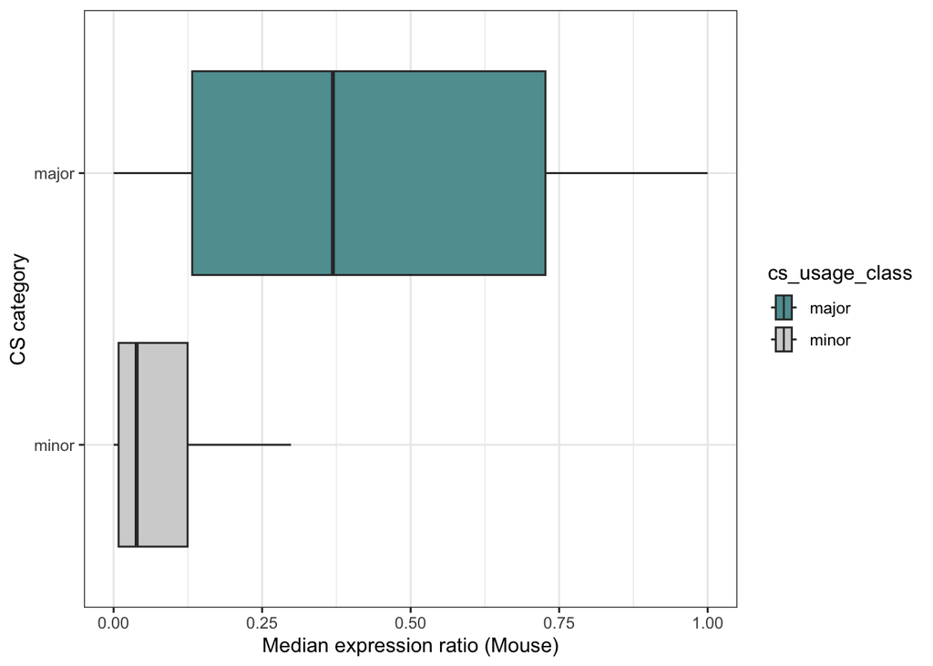

```r
### Plot fractional expression of major and minor isoforms.

plot_expr_majorminor_mm <- atlas_mouse_filt2 %>%
  dplyr::filter(!is.na(cs_usage_class)) %>%
  ggplot(aes(x= median_usage, y=reorder(cs_usage_class, median_usage), fill=cs_usage_class)) +
  geom_boxplot(outlier.shape = NA) +
  scale_fill_manual(values=c("cadetblue", "lightgrey"))+
  scale_x_continuous("Median expression ratio (Mouse)") +
  scale_y_discrete("CS category") +
  theme_bw()
plot_expr_majorminor_mm
```

```r
atlas_mouse_filt2 %>%
  group_by(cs_usage_class) %>%
  dplyr::filter(!is.na(cs_usage_class)) %>%
  summarize(median(median_usage, na.rm=TRUE))
```

| cs_usage_class | median(median_usage, na.rm = TRUE) |
| --- | --- |
| major | 0.36911536 |
| minor | 0.03874806 |

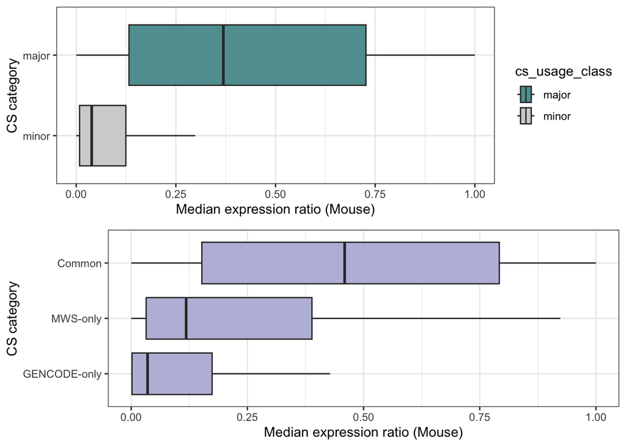

```r
mouse_expr_plots <- grid.arrange(plot_expr_majorminor_mm, plot_expr_commonunique_mm)
```

```r
ggsave("Figure_outputs/Sup_Fig4l.pdf", mouse_expr_plots)
```

Repeat analysis for mouse genes and tissues.

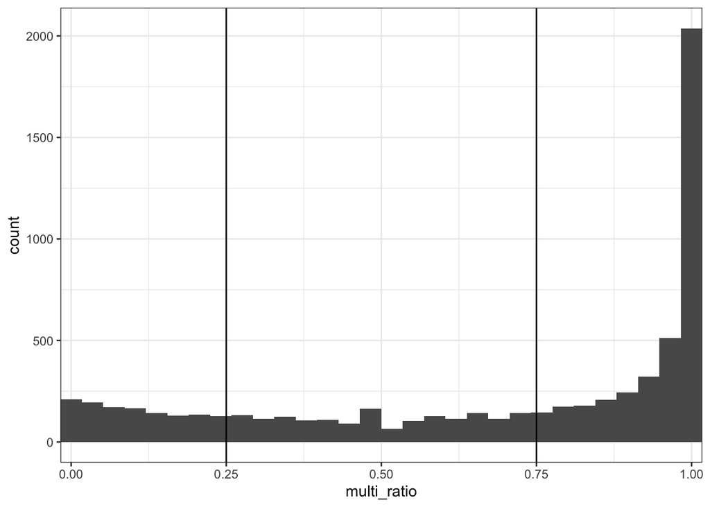

```r
atlas_mouse_filt1.1 <- atlas_mouse_filt1 %>%
  dplyr::filter(is_ipa==FALSE,
                TPM_gene_woIPA > 5,
                frac_tx_to_gene_woIPA > 0.1)

histo_genes_mouse <- atlas_mouse_filt1.1 %>%
  dplyr::filter(atlas.utr_type=="multi") %>%
  group_by(Tissue, gene_name) %>%
  count() %>%
  ungroup() %>%
  mutate(multi=ifelse(n>1, TRUE, FALSE)) %>%
  group_by(gene_name) %>%
  summarize(multi_ratio = mean(multi, na.rm=T))

histogram_mouse <- histo_genes_mouse %>%
  ggplot(aes(x = multi_ratio)) +
  geom_histogram() +
  scale_x_continuous(expand = c(0,0)) +
  geom_vline(xintercept = 0.25) +
  geom_vline(xintercept = 0.75) +
  theme_bw()
histogram_mouse
```

```r
histo_genes_mouse %>% summarize(mean = mean(multi_ratio<0.25))
```

| mean |
| --- |
| 0.1822762 |

```r
histo_genes_mouse %>% summarize(mean = mean(multi_ratio>0.75))
```

| mean |
| --- |
| 0.5551274 |

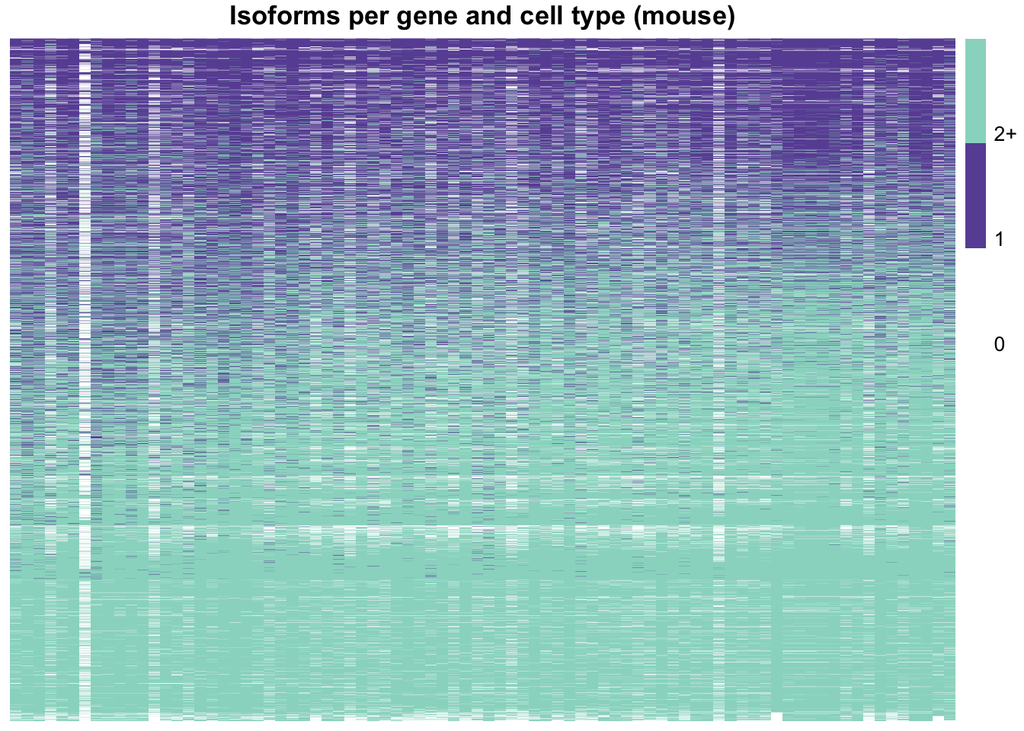

```r
ggsave("Figure_outputs/Sup_Fig4i.pdf", histogram_mouse)
atlas_mouse_filt1_tx <- atlas_mouse_filt1.1 %>%
  group_by(Tissue, gene_name, gene_id) %>%
  count() %>%
  ungroup()

atlas_mouse_multi <- atlas_mouse_filt1_tx %>%
  group_by(Tissue) %>%
  summarize(genes = length(gene_id),
            multi_frac = mean(n>1),
            multi_n = multi_frac*genes) %>%
  dplyr::arrange(multi_frac)

tissue_order_mouse <- atlas_mouse_multi %>%
  pull(Tissue) %>%
  unlist()

gene_order_mouse <- atlas_mouse_filt1.1 %>%
  group_by(Tissue, gene_name) %>%
  count() %>%
  ungroup() %>%
  mutate(multi=ifelse(n>1, TRUE, FALSE)) %>%
  group_by(gene_name) %>%
  summarize(multi_ratio = mean(multi, na.rm=T)) %>%
  dplyr::arrange(multi_ratio)


atlas_mouse_filt1_matrix <- atlas_mouse_filt1.1 %>%
  dplyr::filter(atlas.utr_type=="multi") %>%
  group_by(Tissue, gene_name) %>%
  count() %>%
  ungroup() %>%
  mutate(n=ifelse(n>2, 2, n))%>%
  pivot_wider(id_cols=gene_name, names_from = Tissue, values_from=n) %>%
  column_to_rownames(var="gene_name") %>%
  dplyr::filter(rowMeans(is.na(.)) < 0.5) %>%
  rownames_to_column(var="gene_name") %>%
  replace(is.na(.),0) %>%
  left_join(gene_order_mouse, by= "gene_name") %>%
  dplyr::arrange(multi_ratio) %>%
  dplyr::select(tissue_order_mouse)
breaks=c(0, 0.9, 1.9, 2.9)
color=c("white","#6a51a3","#99d8c9")

heatmap_mouse <- pheatmap(atlas_mouse_filt1_matrix,
         breaks=breaks,
         color=color,
         cluster_rows=F,
         cluster_cols=F,
         show_rownames = FALSE,
         show_colnames = FALSE,
         main= "Isoforms per gene and cell type (mouse)",
         legend_breaks = 0:2,
         legend_labels = c("0","1", "2+"))
```

```r
ggsave("Figure_outputs/Sup_Fig4j.pdf", heatmap_mouse)
```

# Runtime Details

## Conda Environment

[output not shown]

[output cut: 602 more lines]

[output not shown]